# LR Child Death : Descriptive Statistics

UA Research Team

March 28, 2019

# 1 Little Rock Child Death

This report was based on the child death data from Pulaski county between 2012-2019. This report shows the locations and a fitted spatial density map for the deaths reported in this time period and the descriptive statistics for the categorical predictors given in the dataset. Note that for almost all variables there are missing values (often reported as a blank cell or NA) and the descriptive tables also give an idea about their distribution.

## 1.1 Map of Incidents

First we plot the incidents of child death on a map like a point process using the latitude and longitudes extracted by `ggmap`. I have shown only the final map and hidden the R codes.

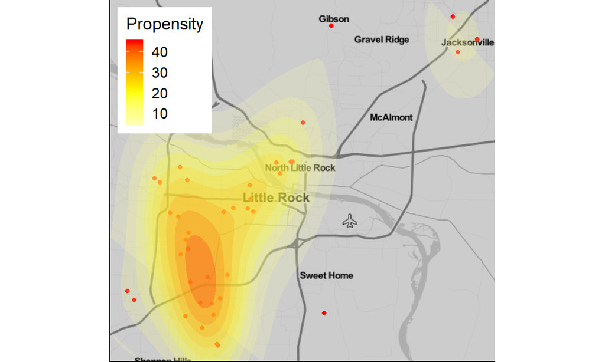

### 1.1.1 Yearly and weekly counts

The stacked barplot below shows the death counts per year (distributed over the weeks).

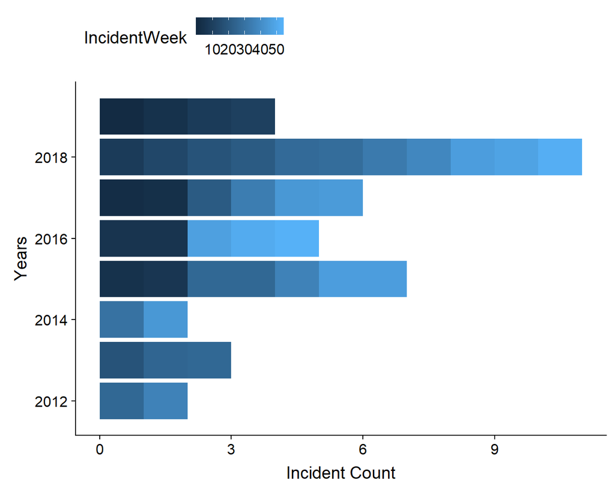

### 1.1.2 Summary Statistics

These were generated using the R package `summarytools`. Please note that the tables report the proportion and count in each category for the 10 categorical predictors provided in the data-set. There was a little bit of data cleaning, e.g. handling different labels (“F” and “Female” for Gender) and multiple values and multiple delimiters in preliminary accusation variable.

I have not yet measured any association or dependence structure in this data.

```r
attach(cd.gc)
get.first.name <- function(cell){
  x<-unlist(str_split(as.character(cell), "\\;|,"))
  return(x[1])
}
cd.gc$Allegation.Prelim.Cause = sapply(Allegation.Prelim.Cause,get.first.name)

cd.gc$Gender = recode(cd.gc$Gender, F = "Female", M = "Male")

library(summarytools)
st_options(dfSummary.na.col = FALSE)
dfSummary(cd.gc[,6:15], plain.ascii = FALSE, style = "grid",
          graph.magnif = 0.75, valid.col = FALSE, tmp.img.dir = "/tmp")
```

### 1.1.3 Data Frame Summary

**cd.gc**  
**Dimensions:** 41 x 10  
**Duplicates:** 0

| No | Variable | Stats / Values | Freqs (% of Valid) | Graph |
| --- | --- | --- | --- | --- |
| 1 | Type.of.Notice [factor] | 1. 2. D/A 3. Investigation | 1 ( 2.4%) 14 (34.2%) 26 (63.4%) |  |
| 2 | Race [factor] | 1. 2. African American 3. Caucasian 4. Hispanic 5. Unable to Determine 6. Unknown | 1 ( 2.4%) 30 (73.2%) 7 (17.1%) 1 ( 2.4%) 1 ( 2.4%) 1 ( 2.4%) |  |
| 3 | Gender [factor] | 1. 2. Female 3. Male | 1 ( 2.4%) 16 (39.0%) 24 (58.5%) |  |
| 4 | County [factor] | 1. 2. Pulaski | 1 ( 2.4%) 40 (97.6%) |  |
| 5 | Placement.of.child.at.time.of.incident [factor] | 1. 2. Foster Care 3. Relative | 2 ( 4.9%) 2 ( 4.9%) 37 (90.2%) |  |
| 6 | Allegation.Prelim.Cause [character] | 1. Inadequate Supervision 2. Other Undetermined Circum 3. Sudden Unexplained Infant 4. Failure to Protect 5. Medical Neglect 6. 7. Accident - ATV 8. Burns 9. Cuts 10. Environmental Neglect [ 7 others … | 14 (34.1%) 6 (14.6%) 5 (12.2%) 2 ( 4.9%) 2 ( 4.9%) 1 ( 2.4%) 1 ( 2.4%) 1 ( 2.4%) 1 ( 2.4%) 1 ( 2.4%) 7 (17.1%) |  |
| 7 | Medical.Injury.Information.Pertaining.to.Fatality.Near.Fatality [factor] | 1. 2. 57% of his body was burne 3. Alcohol poisioning 4. Anoxic brain injury 5. ATV accident 6. Autopsy is undetermined, 7. Autopsy results are not c 8. Blunt force trauma 9. Brain damage 10. Diphenhy… | 2 ( 4.9%) 1 ( 2.4%) 1 ( 2.4%) 1 ( 2.4%) 1 ( 2.4%) 1 ( 2.4%) 1 ( 2.4%) 1 ( 2.4%) 1 ( 2.4%) 1 ( 2.4%) 30 (73.2%) |  |
| 8 | Alleged.Offender.Relationship.to.AV [factor] | 1. 2. N/A 3. Non-Relative 4. Relative 5. Relative; Unknown 6. Relatives 7. Unknown | 2 ( 4.9%) 14 (34.2%) 1 ( 2.4%) 20 (48.8%) 1 ( 2.4%) 1 ( 2.4%) 2 ( 4.9%) |  |
| 9 | Finding [factor] | 1. 2. N/A 3. TRUE 4. UNSUB | 2 ( 4.9%) 14 (34.2%) 18 (43.9%) 7 (17.1%) |  |
| 10 | Prior.DHS.Involvement [factor] | 1. 2. History 3. No History 4. No Prior | 2 ( 4.9%) 15 (36.6%) 22 (53.7%) 2 ( 4.9%) |  |